# 9 Multidimensionality: Continued

Psychologische Institut für psychologische Methodenlehre, Evaluation und Statistik

~

Carolina Fellinghauer

carolina.fellinghauer@uzh.ch

05.08.2020

# Multidimensional Rasch Model

In practice, the unidimensionality assumption does not always hold and a latent trait can be deconstructed into subcomponents. The Rasch model has been developed to accommodate various assessment situations were the data is unidimensional. In the 1990’s, an extension of the Rasch model was proposed named the *Multidimensional Random Coefficient Multinomial Logit (MRCML)* model (Adams, Wilson, and Wang 1997). Free software tools to do this type of analyses only appeared around 2015, with the R-package TAM (Kiefer, Robitzsch, and Wu 2014).

Despite its greater computational complexity, the form of the multidimensional PCM model with Q dimensions can be written in very similar fashion to the unidimensional PCM

$$P(X_{ikn} = k | \theta_{nq}) =
\frac{exp{(\theta_{nq} - \delta_{ik})}}
{\Sigma^{m_i}_{c=0} exp \Sigma_{h=0}^{c} (\theta_{nq} - \delta_{ik})}$$

Two type of multidimensional Rasch models are available, the *“between-item multidimensionality”* and *“within-item multidimensionality”*, which differ in their conceptualization of the loading structure. In the first approach, each item belongs to one dimension. In the second approach, cross-loading is allowed and items can belong to more than dimension (Adams, Wilson, and Wang 1997).

The multidimensional Rasch model is not an explorative analytic approach that is searching for a model with a dimensional structure. It is a *confirmatory approach*, where ahead, the user has to have assumptions about the dimensions of the instrument to calibrate.

Multidimensional modeling assumes that an assessment tool describes more than one single latent trait. Brigg writes that “*the art of assessing dimensionality is to find the smallest number of latent ability domains such that they are both statistically well-defined and substantially meaningful*” (REF: Briggs and Wilson 2003, Journal of Applied Measurement An introduction to Multidimensional Measurement using Rasch Models pp 87-100). Parsimoniously selecting the amount of dimensions benefit the item scoring and test administration.

The fit of various nested models with increasing number of dimensions can be compared with the likelihood ratio test, to determine which model fits best. This allows to and make informed decisions on the number of dimensions to retain.

The library ´eRm´ does not have any functions for multidimensional analysis. Instead, the library ´TAM´or ´mirt´ can be used, this lesson will focus on ´mirt´. But before starting, as they differ, let’s briefly spend a few lines on the estimation methods used by these packages.

Different methods to estimate Rasch parameter can be found: Joint Maximum Likelihood (JML), Conditional Maximum Likelihood (CML), Marginal Maximum Likelihood (MMLE), and Bayesian (e.g. Expected A Posteriori, EAP) estimation. All methods base on the likelihood function, i.e. the probability of the observed data as a function of unknown parameter.

$$L_{u_{ni}} (\theta_n, \delta_i) = P(U_{ni} = u_{ni} | \theta_n, \delta_n) = \frac{exp(u_{ni} \cdot (\theta_n - \delta_n))}{1 + exp(\theta_n - \delta_n)}$$

Let’s briefly introduce two of these estimation methods, CML and MML, and mention the critical standpoint of some Rasch purists in this regard and when it may matter.

# Conditional Maximum Likelihood

Conditional Maximum Likelihood (CML) is by far the preferred estimation method by the classical Rasch methodologists. This approach bases only on what can be observed in the data. CML ‘simply’ replaces each test taker’s person parameter with their corresponding sum score. CML is a two step approach, computing (1) the item difficulty parameter regardless of the person abilities, and only then (2) estimates the person parameter conditionally to the item parameter estimated in (1).

In the CML estimation, the person’s row score $r_p$ is a sufficient statistic for their person parameter $\theta_p$ and the likelihood of a row score can be expressed as

$$L_u(r,\delta) = \frac{exp(-\Sigma^I_{i=1} c_i \cdot \delta_i)}{\prod^N_{n=1} \gamma_{r_n} (\delta) }$$

# Marginal Maximum Likelihood

As CML, Marginal Maximum Likelihood (MML) is not accounting for the person parameter ($\theta$) to estimate the item difficulty ($\delta$), but in this approach, the person parameter are ‘averaged out’.

MML estimation requires a marginal, or population, distribution for the person parameter. This distribution expresses the relative probability of each possible ability parameters. A common choice of population distribution for the person parameters is the normal distribution. This makes sense when we can assume a symmetric distribution where the majority of people have person parameters near the mean.

Just like CML, MML estimates the person parameter in a second step, often called *scoring*.

The package ´mirt´ uses MML to estimate unidimensional and multidimensional Rasch models, while ´eRm´ uses the CML which bases on the observed row scores without any distributional assumptions. That is why the CML methods is the prefered approach for measurement purists.

# Getting ready

Loading the MDS data.

```r
library(eRm)
library(mirt)

# get the MDS dataset from GitHub

urlfile <- "https://raw.githubusercontent.com/CarolinaFellinghauer/UNIZH_HS2020_Rasch/master/Data/WHO_MDS_course.csv?token=AB5GB46B55WMO5AU74G4CKK7K5JSG"

MDS.data <- read.csv(url(urlfile), sep = ";")
colnames(MDS.data)
```

```
FALSE  [1] "ID"            "sex"           "age"           "HealthStatus"
FALSE  [5] "Vision"        "Hearing"       "Walking"       "Memory"
FALSE  [9] "Dressing"      "Communication" "Feeding"       "Toileting"
FALSE [13] "Bed"           "GoingOut"      "Shopping"      "HandUse"
FALSE [17] "Sleeping"      "Breathing"     "Household"     "Caring"
FALSE [21] "Participating" "Depressivity"  "Anxiety"       "GettingAlong"
FALSE [25] "Managing"      "Pain"
```

```r
# Select only the MDS items, these are all columns except the first four.  It
# starts with vision.

mds.items <- colnames(MDS.data)[-(1:4)]

data.mds <- MDS.data[, mds.items]
data.mds <- data.mds - 1
```

# Diagnostics

Now that this has been clarified let’s start with the multidimensional Rasch analysis with library ´mirt´. The unidimensional Rasch model, including the Partial Credit Model, can be run simply by specifying the option ´itemtype = Rasch´.

```r
mds.1dim <- mirt(data.mds, 1, itemtype = "Rasch", verbose = FALSE)
```

Based on the previous lesson, the items which go in dimension 1 or dimension 2 are determined through their loading sign on the first principal component. The package ´mirt´ does not provide the analysis residuals as ´eRm´ does, but it provides the residual correlation matrix, the Q3-statistic, which is sufficient to do a PCA with ´prcomp()´ which requires as input the data’s correlation matrix.

```r
cor.mds <- residuals(mds.1dim, type = "Q3", verbose = FALSE)  #gives the correlation of the standardized residuals

PCA.mds <- prcomp(cor.mds, center = TRUE, retx = TRUE)  #PCA
which(PCA.mds$rotation[, "PC1"] < 0)  # negative sign on PC1
```

```
FALSE        Vision       Hearing        Memory Communication       HandUse
FALSE             1             2             4             6            12
FALSE      Sleeping     Breathing  Depressivity       Anxiety  GettingAlong
FALSE            13            14            18            19            20
FALSE          Pain
FALSE            22
```

```r
which(PCA.mds$rotation[, "PC1"] > 0)  # positive sign on PC1
```

```
FALSE       Walking      Dressing       Feeding     Toileting           Bed
FALSE             3             5             7             8             9
FALSE      GoingOut      Shopping     Household        Caring Participating
FALSE            10            11            15            16            17
FALSE      Managing
FALSE            21
```

The signs of the first PC1 help determining which items fall into which dimension.

- Dimension 1: Vision (1), Hearing (2), Memory (4), Communication (6), HandUse (12), Sleeping (13), Breathing (14), Depressivity (18), Anxiety (19), GettingAlong (20), Pain (22)
- Dimension 2: Walking (3), Dressing (5), Feeding (7), Toileting (8), Bed (9), GoingOut (10), Shopping (11), Household (15), Caring (16), Participating (17), Managing (21)

This finding is also consistent with what was found earlier, when doing the PCA with the correlation of the standardized residuals computed with the package ´eRm´ (Exercise: *8: Multidimensionality*).

The function ´mirt()´ allows to fit the IRT model. Rasch analysis in ´mirt´ works only for unidimensional models. For multidimensional models, the closest parameterization to the Partial Credit Model is ´gpcm´, the Generalized Partical Credit Model (GPCM). The GPCM from Muraki (Muraki 1992) is an IRT model, more specifically a 2-PL model, where the item discrimination slope is allowed to vary across items.

The GPCM is an extension of the PCM model (and so also of the RSM) with itemwise unconstrained slope parameter, i.e. with an additional parameter for the item discrimination $a_i$. It uses a score category response function to estimate the probability of a response $X_{ijk}$ and is formalized as:

$$P(X_{ikj}= k | \theta_j) =
\frac{exp \Sigma_{h=0}^k a_i(\theta_j - \delta_{ik})}
{ \Sigma^{m_i}_{c=0} exp \Sigma_{h=0}^{c}[a_i(\theta_j - \delta_{ik})]}$$

or parameterized with location ($\delta$) plus deviation ($\lambda$):

$$P(X_{ikj} = k | \theta_j) =
\frac{exp \Sigma_{h=0}^k a_i(\theta_j - \delta_{i} + \lambda_{ik})}
{\Sigma^{m_i}_{c=0} exp \Sigma_{h=0}^{c}[a_i(\theta_j - \delta_{i} + \lambda_{ik})]}$$

However, it is possibly to obtain a PCM parameterization, by constraining the item discrimination $a_i$ to be 1 for all items. The following code presets the parameterization for a 2 dimensional Rasch model with the items in two dimension as found with the PCA previously.

```r
spec1 <- "
              F1 = 1, 2, 4, 6, 12, 13, 14, 18, 19, 20, 22
              F2 = 3, 5, 7, 8, 9, 10, 11, 15, 16, 17, 21
              START = (1, 2, 4, 6, 12, 13, 14, 18, 19, 20, 22, a1, 1.0)
              START = (3, 5, 7, 8, 9, 10, 11, 15, 16, 17, 21, a2, 1.0)
              FIXED = (1, 2, 4, 6, 12, 13, 14, 18, 19, 20, 22, a1)
              FIXED = (3, 5, 7, 8, 9, 10, 11, 15, 16, 17, 21, a2)
              FREE = (GROUP, COV11)
              FREE = (GROUP, COV22)
              COV = F1*F2 "
```

```r
mds.2dim <- mirt(data.mds, model = spec1, itemtype = "gpcm", verbose = FALSE)
```

Nested models can be compared using among others Akaike Information Criterion (AIC) and Bayesian Information Criterion (BIC) where smaller values indicate a better fit and the likelihood ratio test (X2) indicate if the change in fit is significant.

```r
anova(mds.1dim, mds.2dim, verbose = FALSE)
```

```
FALSE        AIC     AICc    SABIC       HQ      BIC    logLik      X2  df   p
FALSE 1 49431.23 49448.84 49585.35 49597.24 49868.02 -24626.62     NaN NaN NaN
FALSE 2 48553.40 48571.00 48707.52 48719.41 48990.19 -24187.70 877.836   0   0
```

The likelihood ratio test is highly significant, indicating that the fit, improved signficantly from one to two-dimensional model, as the AIC estimates become smaller in the 2 dimensional model.

The next step wants to test if a 3 dimensional approach is even better. First, we visually inspect the items to determine with items belong to which dimension. This is an iterative approach, a little bit of trial and error based on the visual analysis outputs.

The loading on the principal components give us the best indication on which items belong together.

```r
PCA.mds$rotation[, c(1:3)]
```

```
                      PC1          PC2         PC3
Vision        -0.14150675  0.036594887  0.35616844
Hearing       -0.12499411  0.129445466  0.13120996
Walking        0.19218147  0.059516734  0.37812525
Memory        -0.17182259  0.173572538 -0.23496063
Dressing       0.25574130  0.321743171 -0.12740329
Communication -0.05359306  0.170224310 -0.47411383
Feeding        0.09911110  0.326777928 -0.20200469
Toileting      0.28660023  0.274026202 -0.12716550
Bed            0.27866895  0.222105591  0.02196402
GoingOut       0.30477770 -0.175728435  0.13116727
Shopping       0.30095687 -0.185296273  0.11897875
HandUse       -0.04336476  0.149521940 -0.01065858
Sleeping      -0.21227974  0.005578764  0.13175887
Breathing     -0.18333043  0.069156335  0.20089696
Household      0.27413462 -0.248751080  0.02067644
Caring         0.17348233 -0.337356864 -0.14214376
Participating  0.11312412 -0.340675296 -0.11736084
Depressivity  -0.33135477 -0.121739831 -0.03380616
Anxiety       -0.32942009 -0.139950755 -0.03445224
GettingAlong  -0.20549164 -0.183845918 -0.29197320
Managing       0.07075036 -0.350600001 -0.16913133
Pain          -0.11132821  0.096313808  0.34566458
```

First, let’s observe again the 2 dimensional principal component plot.

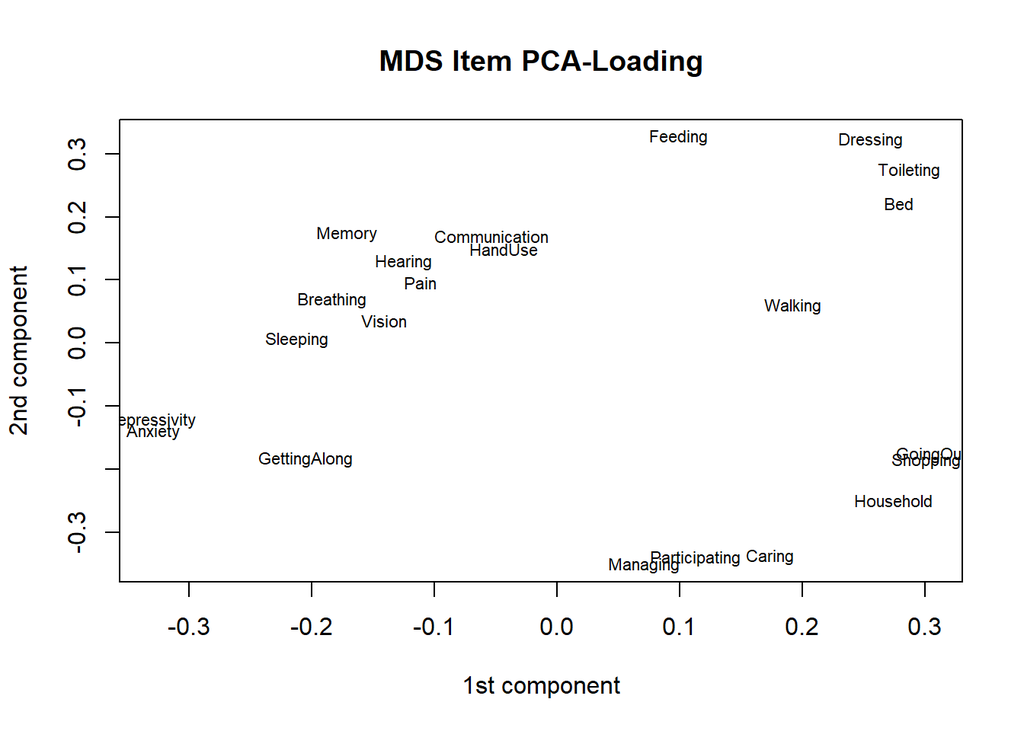

Figure 3

and complement the information with a 3-dimensional representation of the loadings of the 3 first principal components.

```r
Dataset <- as.data.frame(PCA.mds$rotation)
Dataset <- cbind(id = rownames(Dataset), Dataset)

plot3d(Dataset$PC1, Dataset$PC2, Dataset$PC3, xlab = "PC1", ylab = "PC2", zlab = "PC3",
    type = "s", radius = 0, col = "white")
text3d(Dataset$PC1, Dataset$PC2, Dataset$PC3, texts = rownames(Dataset))
```

[interactive chart not shown]

To find the best 3-dimensional design may require additional testing. For the example, and based on the component loadings and the 3-dimensional graphical visualization.

- Dimension 1: Memory (4), Communication (6), HandUse (12), GettingAlong (20)
- Dimension 2: Vision (1), Hearing (2), Sleeping (13), Breathing (14), Depressivity (18), Anxiety (19), Pain (22)
- Dimension 3: Walking (3), Dressing (5), Feeding (7), Toileting (8), Bed (9), GoingOut (10), Shopping (11), Household (15), Caring (16), Participating (17), Managing (21)

Here again, to do the Rasch analysis the item slope parameter have to be fixed.

```r
spec2 <- "
              F1 = 4, 6, 12, 20
              F2 = 1, 2, 13, 14, 18, 19, 22
              F3 = 3, 5, 7, 8, 9, 10, 11, 15, 16, 17, 21
              START = (4, 6, 12, 20, a1, 1.0)
              START = (1, 2, 13, 14, 18, 19, 22, a2, 1.0)
              START = (3, 5, 7, 8, 9, 10, 11, 15, 16, 17, 21, a3, 1.0)
              FIXED = (4, 6, 12, 20, a1)
              FIXED = (1, 2, 13, 14, 18, 19, 22, a2)
              FIXED = (3, 5, 7, 8, 9, 10, 11, 15, 16, 17, 21, a3)
              FREE = (GROUP, COV11)
              FREE = (GROUP, COV22)
              FREE = (GROUP, COV33)
              COV = F1*F2, F1*F3, F2*F3"
```

The Rasch model is computed

```r
mds.3dim <- mirt(data.mds, model = spec2, itemtype = "gpcm", verbose = FALSE)
anova(mds.2dim, mds.3dim)
```

```
Model 1: mirt(data = data.mds, model = spec1, itemtype = "gpcm", verbose = FALSE)
Model 2: mirt(data = data.mds, model = spec2, itemtype = "gpcm", verbose = FALSE)
```

```
       AIC    AICc    SABIC       HQ      BIC    logLik      X2  df   p
1 48553.40 48571.0 48707.52 48719.41 48990.19 -24187.70     NaN NaN NaN
2 48326.36 48344.8 48483.94 48496.10 48772.96 -24072.18 231.037   2   0
```

Three dimensional is even better than two dimensional, the AIC becomes smaller with 3 dimensions, the $X2$ supports the change is significant.

This lesson showed how a model structure could be selected using the multidimensional Rasch model and the likelihood ratio test to compare nested models. However, in practice, the model is not only selected based on the best model fit. Other model characteristics such as the item fit for example or the reliability are also important to account for.

Note that the reliability of the models can be found using ´empirical_rxx()´:

```r
empirical_rxx(fscores(mds.1dim, full.scores.SE = TRUE))
```

```
       F1
0.9496832
```

```r
empirical_rxx(fscores(mds.2dim, full.scores.SE = TRUE))
```

```
       F1        F2
0.9243118 0.9337464
```

```r
empirical_rxx(fscores(mds.3dim, full.scores.SE = TRUE))
```

```
       F1        F2        F3
0.9142233 0.9030495 0.9379635
```

and the item fit can be extracted using ´itemfit()´:

```r
itemfit(mds.1dim, fit_stats = "infit")
```

```
            item outfit z.outfit infit z.infit
1         Vision  1.870   12.962 1.831  14.683
2        Hearing  2.123    9.299 1.619  10.564
3        Walking  0.645   -5.912 0.742  -5.940
4         Memory  1.048    0.827 1.153   3.317
5       Dressing  0.618   -5.183 0.710  -6.844
6  Communication  0.834   -1.526 0.918  -1.579
7        Feeding  0.493   -5.573 0.682  -6.957
8      Toileting  0.416   -6.205 0.618  -8.857
9            Bed  0.445   -8.075 0.587 -10.227
10      GoingOut  0.417   -8.065 0.577 -10.034
11      Shopping  0.420   -7.387 0.583  -9.588
12       HandUse  0.760   -3.074 0.940  -1.303
13      Sleeping  1.073    1.173 1.145   3.055
14     Breathing  1.473    6.120 1.465   8.897
15     Household  0.603   -5.614 0.655  -8.244
16        Caring  0.603   -4.633 0.732  -5.988
17 Participating  0.674   -3.683 0.803  -4.131
18  Depressivity  0.963   -0.643 1.070   1.532
19       Anxiety  1.026    0.512 1.105   2.301
20  GettingAlong  1.140    1.301 1.090   1.686
21      Managing  0.651   -4.780 0.729  -6.330
22          Pain  1.252    4.005 1.089   1.838
```

```r
itemfit(mds.2dim, fit_stats = "infit")
```

```
            item outfit z.outfit infit z.infit
1         Vision  1.512    8.557 1.515   9.937
2        Hearing  1.543    5.473 1.364   6.672
3        Walking  0.665   -5.990 0.777  -4.824
4         Memory  0.822   -3.377 0.907  -2.215
5       Dressing  0.609   -5.521 0.684  -6.962
6  Communication  0.729   -2.835 0.859  -2.790
7        Feeding  0.568   -4.603 0.796  -3.940
8      Toileting  0.348   -7.462 0.512 -10.837
9            Bed  0.412   -9.184 0.547 -10.585
10      GoingOut  0.355   -9.794 0.506 -11.176
11      Shopping  0.351   -9.096 0.507 -10.740
12       HandUse  0.678   -4.623 0.865  -3.161
13      Sleeping  0.818   -3.322 0.886  -2.666
14     Breathing  1.158    2.383 1.189   3.955
15     Household  0.511   -7.809 0.586  -9.513
16        Caring  0.603   -4.885 0.758  -4.891
17 Participating  0.650   -4.129 0.883  -2.162
18  Depressivity  0.687   -6.517 0.752  -6.167
19       Anxiety  0.747   -5.414 0.796  -5.007
20  GettingAlong  0.838   -1.706 0.888  -2.207
21      Managing  0.700   -4.303 0.846  -3.192
22          Pain  1.023    0.422 0.946  -1.170
```

```r
itemfit(mds.3dim, fit_stats = "infit")
```

```
            item outfit z.outfit infit z.infit
1         Vision  1.368    6.452 1.415   8.225
2        Hearing  1.418    4.392 1.317   5.864
3        Walking  0.726   -4.749 0.847  -3.205
4         Memory  0.819   -3.421 0.930  -1.597
5       Dressing  0.614   -5.394 0.714  -6.152
6  Communication  0.639   -3.838 0.771  -4.537
7        Feeding  0.589   -4.263 0.822  -3.408
8      Toileting  0.383   -6.791 0.559  -9.170
9            Bed  0.440   -8.526 0.590  -9.336
10      GoingOut  0.391   -8.960 0.572  -8.992
11      Shopping  0.380   -8.457 0.566  -8.705
12       HandUse  0.634   -5.288 0.817  -4.244
13      Sleeping  0.776   -4.228 0.841  -3.776
14     Breathing  1.005    0.095 1.042   0.926
15     Household  0.540   -7.163 0.624  -8.292
16        Caring  0.647   -4.208 0.824  -3.434
17 Participating  0.702   -3.412 0.969  -0.511
18  Depressivity  0.624   -8.180 0.689  -7.950
19       Anxiety  0.668   -7.439 0.715  -7.252
20  GettingAlong  0.847   -1.557 0.957  -0.776
21      Managing  0.749   -3.495 0.919  -1.609
22          Pain  0.912   -1.614 0.890  -2.421
```

Exercise: Challenge : Find a better fitting 3 dimensional model using the MDS-data.

Adams, Raymond J., Mark Wilson, and Wen-chung Wang. 1997. “The Multidimensional Random Coefficients Multinomial Logit Model.” *Applied Psychological Measurement* 21 (1): 1–23. https://doi.org/10.1177/0146621697211001.

Kiefer, Thomas, Alexander Robitzsch, and Margaret Wu. 2014. “TAM: Test Analysis Modules.”

Muraki, Eiji. 1992. “A Generalized Partial Credit Model: Application of an Em Algorithm.” *Applied Psychological Measurement* 16 (2): 159–76. https://doi.org/10.1177/014662169201600206.